# SQ A2CW1001

## Shared Qs (A2CW1001)

#### Question

1. In the graph below, we see $y=f(x)$ as a blue line and $y=g(x)$ as a red line.

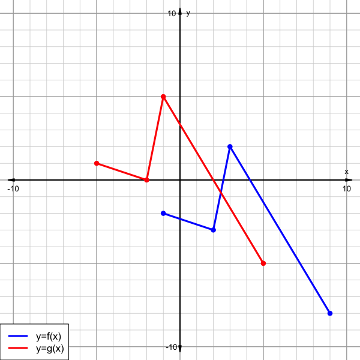

   We can see that $g$ is a translated version of $f$. Which equation describes this transformation?
   1. $g(x)~=~f(x-3)-4$
   2. $g(x)~=~f(x-3)+4$
   3. $g(x)~=~f(x-4)-3$
   4. $g(x)~=~f(x-4)+3$
   5. $g(x)~=~f(x+3)-4$
   6. $g(x)~=~f(x+3)+4$
   7. $g(x)~=~f(x+4)-3$
   8. $g(x)~=~f(x+4)+3$

#### Solution

#### Question

2. In the graph below, we see $y=f(x)$ as a blue line and $y=g(x)$ as a red line.

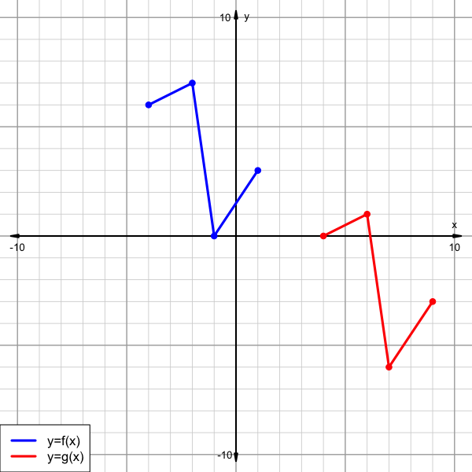

   We can see that $g$ is a translated version of $f$. Which equation describes this transformation?
   1. $g(x)~=~f(x-6)-8$
   2. $g(x)~=~f(x-6)+8$
   3. $g(x)~=~f(x-8)-6$
   4. $g(x)~=~f(x-8)+6$
   5. $g(x)~=~f(x+6)-8$
   6. $g(x)~=~f(x+6)+8$
   7. $g(x)~=~f(x+8)-6$
   8. $g(x)~=~f(x+8)+6$

#### Solution

#### Question

3. In the graph below, we see $y=f(x)$ as a blue line and $y=g(x)$ as a red line.

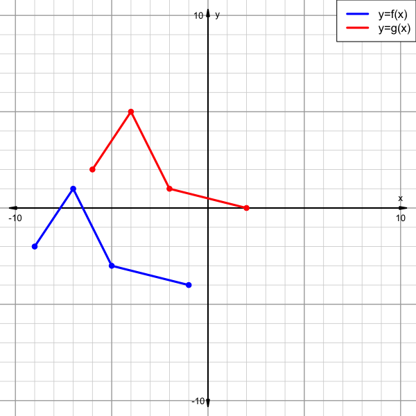

   We can see that $g$ is a translated version of $f$. Which equation describes this transformation?
   1. $g(x)~=~f(x-3)-4$
   2. $g(x)~=~f(x-3)+4$
   3. $g(x)~=~f(x-4)-3$
   4. $g(x)~=~f(x-4)+3$
   5. $g(x)~=~f(x+3)-4$
   6. $g(x)~=~f(x+3)+4$
   7. $g(x)~=~f(x+4)-3$
   8. $g(x)~=~f(x+4)+3$

#### Solution

#### Question

4. In the graph below, we see $y=f(x)$ as a blue line and $y=g(x)$ as a red line.

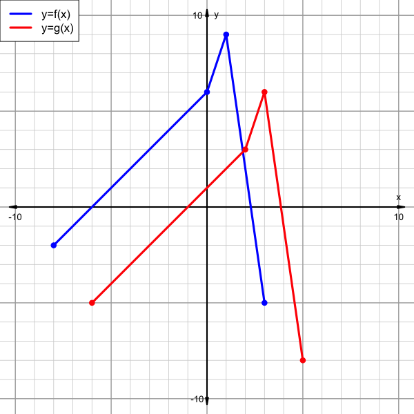

   We can see that $g$ is a translated version of $f$. Which equation describes this transformation?
   1. $g(x)~=~f(x-2)-3$
   2. $g(x)~=~f(x-2)+3$
   3. $g(x)~=~f(x-3)-2$
   4. $g(x)~=~f(x-3)+2$
   5. $g(x)~=~f(x+2)-3$
   6. $g(x)~=~f(x+2)+3$
   7. $g(x)~=~f(x+3)-2$
   8. $g(x)~=~f(x+3)+2$

#### Solution

#### Question

5. In the graph below, we see $y=f(x)$ as a blue line and $y=g(x)$ as a red line.

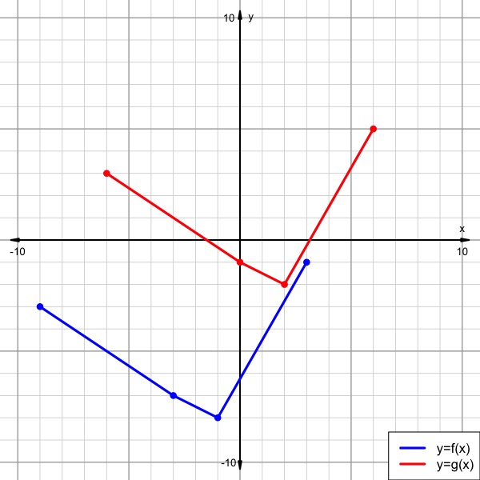

   We can see that $g$ is a translated version of $f$. Which equation describes this transformation?
   1. $g(x)~=~f(x-3)-6$
   2. $g(x)~=~f(x-3)+6$
   3. $g(x)~=~f(x-6)-3$
   4. $g(x)~=~f(x-6)+3$
   5. $g(x)~=~f(x+3)-6$
   6. $g(x)~=~f(x+3)+6$
   7. $g(x)~=~f(x+6)-3$
   8. $g(x)~=~f(x+6)+3$

#### Solution

#### Question

6. Let $f$ be a function. Solutions to $f[a]=b$ are shown as rows in the table:

   | $a$ | $b$ |
   | --- | --- |
   | 28 | 64 |
   | 36 | 49 |
   | 69 | 17 |

   Each $(a,b)$ solution has a corresponding $(x,y)$ solution to the equation below.

   $$y~=~f(x-2)-4$$

   Express the corresponding solutions in the same order.

   | $x$ | $y$ |
   | --- | --- |

#### Solution

#### Question

7. Let $f$ be a function. Solutions to $f[a]=b$ are shown as rows in the table:

   | $a$ | $b$ |
   | --- | --- |
   | 10 | 49 |
   | 54 | 67 |
   | 68 | 55 |

   Each $(a,b)$ solution has a corresponding $(x,y)$ solution to the equation below.

   $$y~=~f(x+1)-5$$

   Express the corresponding solutions in the same order.

   | $x$ | $y$ |
   | --- | --- |

#### Solution

#### Question

8. Let $f$ be a function. Solutions to $f[a]=b$ are shown as rows in the table:

   | $a$ | $b$ |
   | --- | --- |
   | 33 | 17 |
   | 51 | 82 |
   | 57 | 44 |

   Each $(a,b)$ solution has a corresponding $(x,y)$ solution to the equation below.

   $$y~=~f(x-5)-2$$

   Express the corresponding solutions in the same order.

   | $x$ | $y$ |
   | --- | --- |

#### Solution

#### Question

9. Let $f$ be a function. Solutions to $f[a]=b$ are shown as rows in the table:

   | $a$ | $b$ |
   | --- | --- |
   | 15 | 74 |
   | 71 | 48 |
   | 85 | 23 |

   Each $(a,b)$ solution has a corresponding $(x,y)$ solution to the equation below.

   $$y~=~f(x-1)+4$$

   Express the corresponding solutions in the same order.

   | $x$ | $y$ |
   | --- | --- |

#### Solution

#### Question

10. Let $f$ be a function. Solutions to $f[a]=b$ are shown as rows in the table:

    | $a$ | $b$ |
    | --- | --- |
    | 64 | 49 |
    | 86 | 40 |
    | 90 | 23 |

    Each $(a,b)$ solution has a corresponding $(x,y)$ solution to the equation below.

    $$y~=~f(x+1)+3$$

    Express the corresponding solutions in the same order.

    | $x$ | $y$ |
    | --- | --- |

#### Solution

#### Question

11. Let $f$ be a function. Solutions to $b=f[a]$ are shown as rows in the table:

    | $a$ | $b$ |
    | --- | --- |
    | -30 | 24 |
    | -18 | -6 |
    | -6 | 30 |
    | 18 | 12 |

    Each $(a,b)$ solution has a corresponding $(x,y)$ solution to the equation below.

    $$y~=~ \frac{f(3\cdot x)}{2}$$

    Express the corresponding solutions in the same order.

    | $x$ | $y$ |
    | --- | --- |

#### Solution

#### Question

12. Let $f$ be a function. Solutions to $b=f[a]$ are shown as rows in the table:

    | $a$ | $b$ |
    | --- | --- |
    | -24 | 12 |
    | 6 | -6 |
    | 12 | 30 |
    | 30 | -30 |

    Each $(a,b)$ solution has a corresponding $(x,y)$ solution to the equation below.

    $$y~=~\frac{f{\left(\frac{x}{3}\right)}}{2}$$

    Express the corresponding solutions in the same order.

    | $x$ | $y$ |
    | --- | --- |

#### Solution

#### Question

13. Let $f$ be a function. Solutions to $b=f[a]$ are shown as rows in the table:

    | $a$ | $b$ |
    | --- | --- |
    | -30 | 30 |
    | -18 | -18 |
    | -6 | -24 |
    | 24 | -12 |

    Each $(a,b)$ solution has a corresponding $(x,y)$ solution to the equation below.

    $$y~=~3\cdot f{\left(\frac{x}{2}\right)}$$

    Express the corresponding solutions in the same order.

    | $x$ | $y$ |
    | --- | --- |

#### Solution

#### Question

14. Let $f$ be a function. Solutions to $b=f[a]$ are shown as rows in the table:

    | $a$ | $b$ |
    | --- | --- |
    | -6 | -18 |
    | 18 | 24 |
    | 24 | 18 |
    | 30 | -24 |

    Each $(a,b)$ solution has a corresponding $(x,y)$ solution to the equation below.

    $$y~=~ \frac{f(2\cdot x)}{3}$$

    Express the corresponding solutions in the same order.

    | $x$ | $y$ |
    | --- | --- |

#### Solution

#### Question

15. Let $f$ be a function. Solutions to $b=f[a]$ are shown as rows in the table:

    | $a$ | $b$ |
    | --- | --- |
    | -30 | -6 |
    | -12 | -24 |
    | -6 | 18 |
    | 30 | 30 |

    Each $(a,b)$ solution has a corresponding $(x,y)$ solution to the equation below.

    $$y~=~\frac{f{\left(\frac{x}{3}\right)}}{2}$$

    Express the corresponding solutions in the same order.

    | $x$ | $y$ |
    | --- | --- |

#### Solution

#### Question

16. Let function $g$ be defined as a transformation of function $f$.

    $$g(x)= f{\left(3\cdot x\right)}$$

    The blue curve represents $y=f(x)$. The red curve represents $y=g(x)$.

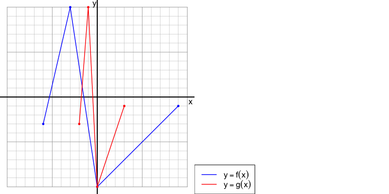

#### Solution

#### Question

17. Let function $g$ be defined as a transformation of function $f$.

    $$g(x)= f{\left(3\cdot x\right)}$$

    The blue curve represents $y=f(x)$. The red curve represents $y=g(x)$.

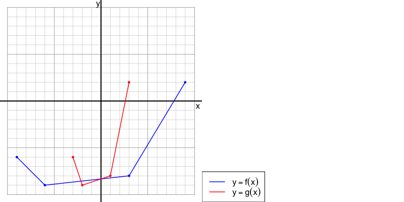

#### Solution

#### Question

18. Let function $g$ be defined as a transformation of function $f$.

    $$g(x)= f{\left(2\cdot x\right)}$$

    The blue curve represents $y=f(x)$. The red curve represents $y=g(x)$.

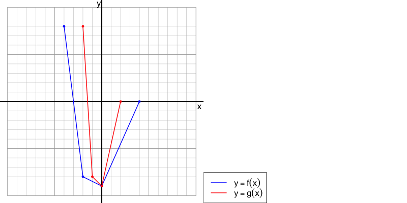

#### Solution

#### Question

19. Let function $g$ be defined as a transformation of function $f$.

    $$g(x)= f{\left(2\cdot x\right)}$$

    The blue curve represents $y=f(x)$. The red curve represents $y=g(x)$.

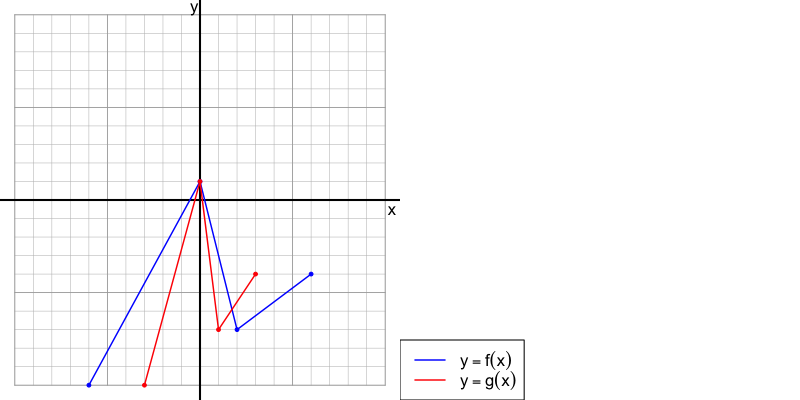

#### Solution

#### Question

20. Let function $g$ be defined as a transformation of function $f$.

    $$g(x)= f{\left(3\cdot x\right)}$$

    The blue curve represents $y=f(x)$. The red curve represents $y=g(x)$.

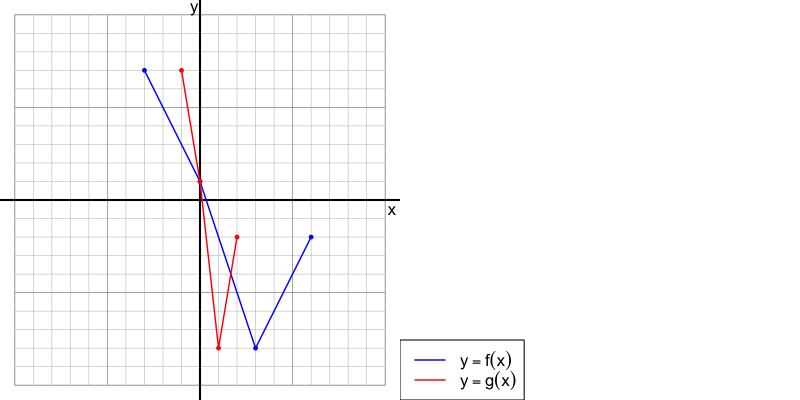

#### Solution

#### Question

21. Let function $g$ be defined as a transformation of function $f$.

    $$g(x)= f{\left(\frac{x}{3}\right)}$$

    The blue curve represents $y=f(x)$. The red curve represents $y=g(x)$.

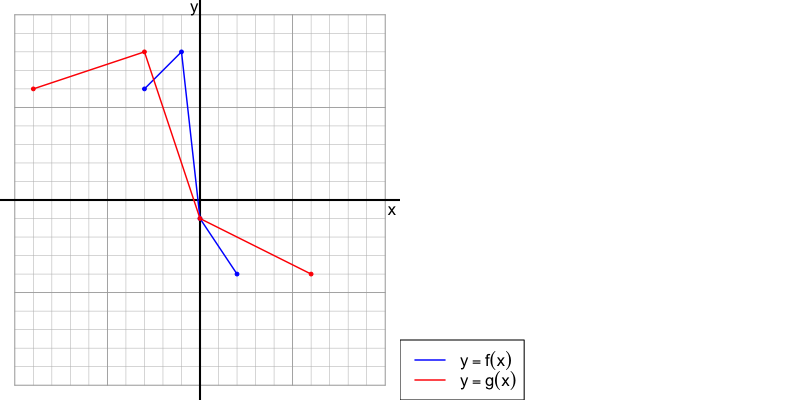

#### Solution

#### Question

22. Let function $g$ be defined as a transformation of function $f$.

    $$g(x)= f{\left(\frac{x}{2}\right)}$$

    The blue curve represents $y=f(x)$. The red curve represents $y=g(x)$.

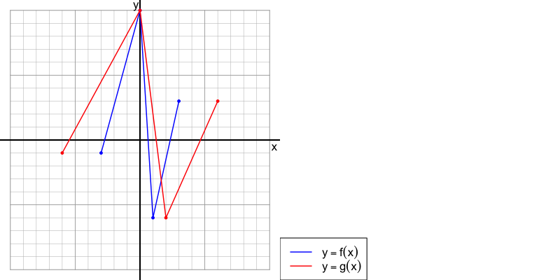

#### Solution

#### Question

23. Let function $g$ be defined as a transformation of function $f$.

    $$g(x)= f{\left(\frac{x}{3}\right)}$$

    The blue curve represents $y=f(x)$. The red curve represents $y=g(x)$.

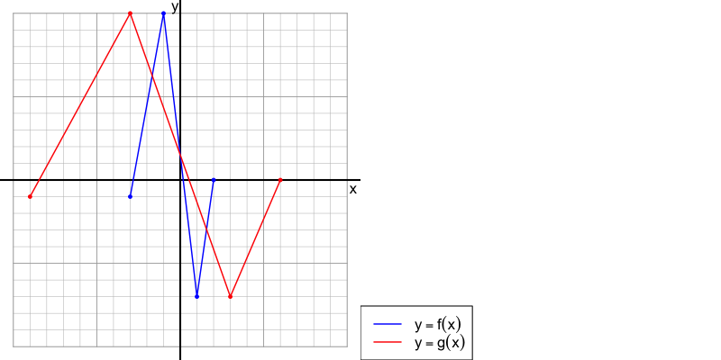

#### Solution

#### Question

24. Let function $g$ be defined as a transformation of function $f$.

    $$g(x)= f{\left(\frac{x}{2}\right)}$$

    The blue curve represents $y=f(x)$. The red curve represents $y=g(x)$.

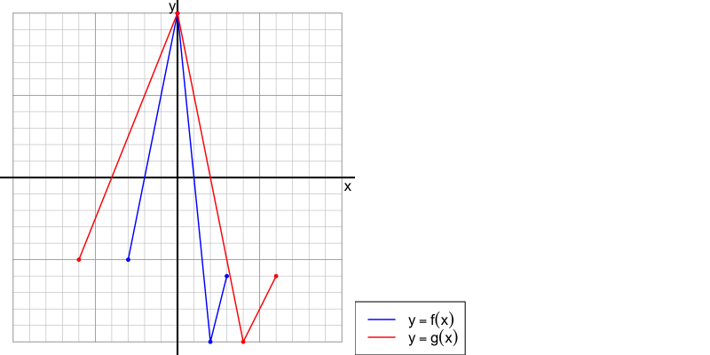

#### Solution

#### Question

25. Let function $g$ be defined as a transformation of function $f$.

    $$g(x)= f{\left(\frac{x}{2}\right)}$$

    The blue curve represents $y=f(x)$. The red curve represents $y=g(x)$.

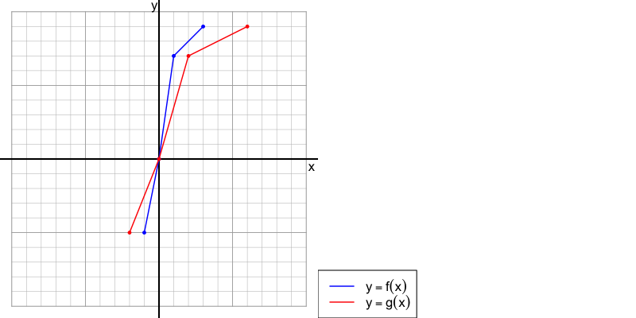

#### Solution

#### Question

26. Let function $g$ be defined as a transformation of function $f$.

    $$g(x)=\frac{f(x)}{3}$$

    The blue curve represents $y=f(x)$. The red curve represents $y=g(x)$.

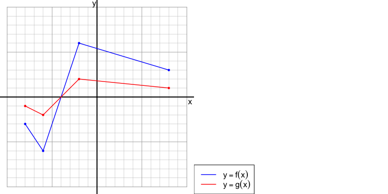

#### Solution

#### Question

27. Let function $g$ be defined as a transformation of function $f$.

    $$g(x)=\frac{f(x)}{2}$$

    The blue curve represents $y=f(x)$. The red curve represents $y=g(x)$.

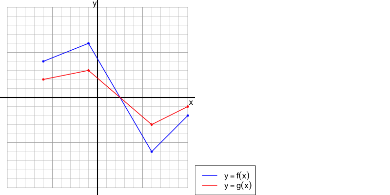

#### Solution

#### Question

28. Let function $g$ be defined as a transformation of function $f$.

    $$g(x)=\frac{f(x)}{3}$$

    The blue curve represents $y=f(x)$. The red curve represents $y=g(x)$.

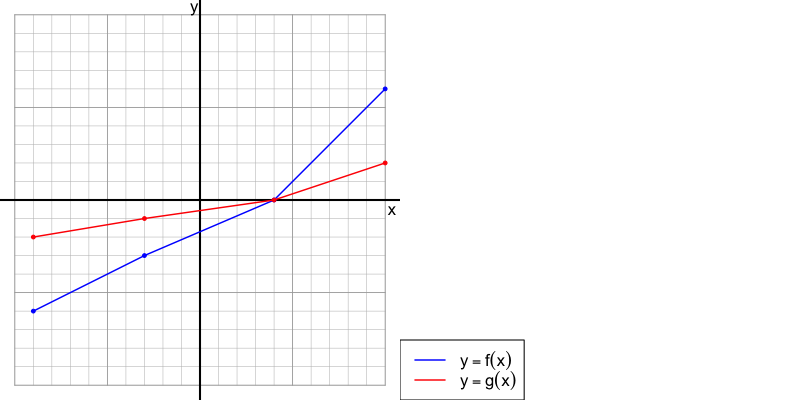

#### Solution

#### Question

29. Let function $g$ be defined as a transformation of function $f$.

    $$g(x)=\frac{f(x)}{2}$$

    The blue curve represents $y=f(x)$. The red curve represents $y=g(x)$.

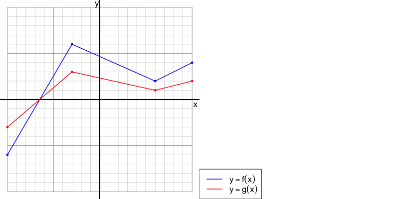

#### Solution

#### Question

30. Let function $g$ be defined as a transformation of function $f$.

    $$g(x)=\frac{f(x)}{2}$$

    The blue curve represents $y=f(x)$. The red curve represents $y=g(x)$.

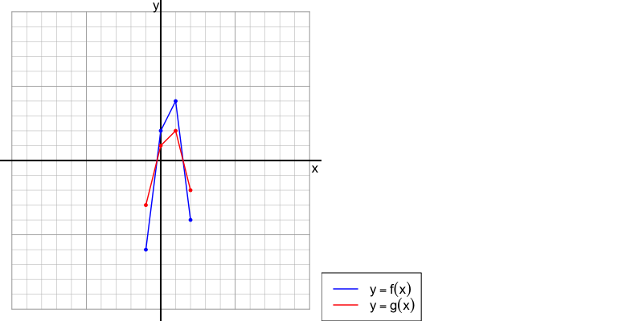

#### Solution

#### Question

31. Let function $g$ be defined as a transformation of function $f$.

    $$g(x)=3\cdot f(x)$$

    The blue curve represents $y=f(x)$. The red curve represents $y=g(x)$.

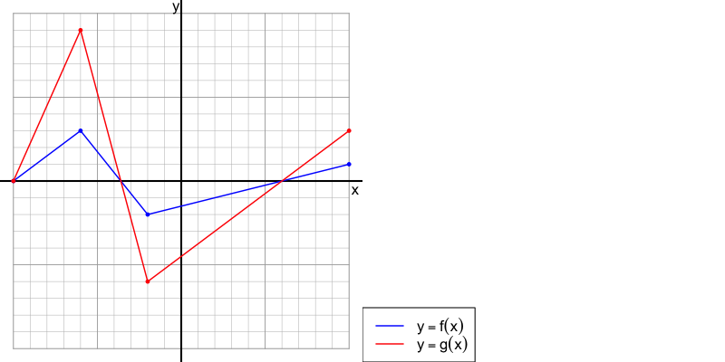

#### Solution

#### Question

32. Let function $g$ be defined as a transformation of function $f$.

    $$g(x)=3\cdot f(x)$$

    The blue curve represents $y=f(x)$. The red curve represents $y=g(x)$.

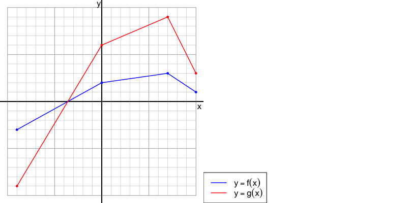

#### Solution

#### Question

33. Let function $g$ be defined as a transformation of function $f$.

    $$g(x)=3\cdot f(x)$$

    The blue curve represents $y=f(x)$. The red curve represents $y=g(x)$.

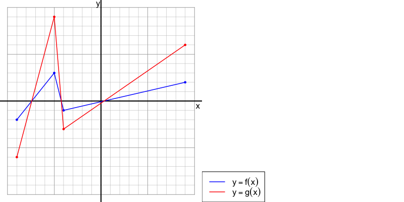

#### Solution

#### Question

34. Let function $g$ be defined as a transformation of function $f$.

    $$g(x)=3\cdot f(x)$$

    The blue curve represents $y=f(x)$. The red curve represents $y=g(x)$.

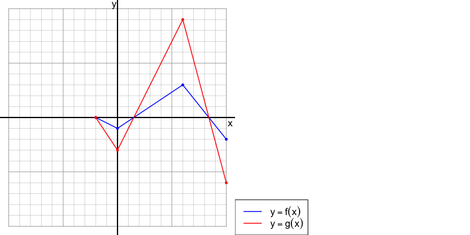

#### Solution

#### Question

35. Let function $g$ be defined as a transformation of function $f$.

    $$g(x)=3\cdot f(x)$$

    The blue curve represents $y=f(x)$. The red curve represents $y=g(x)$.

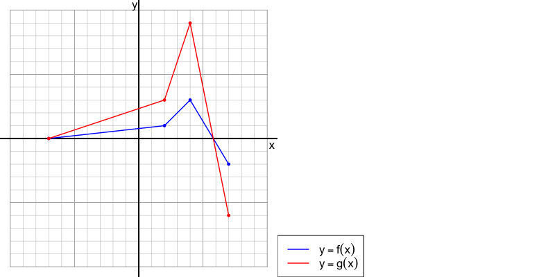

#### Solution

#### Question

36. The blue curve represents $y=f(x)$. The red curve represents $y=g(x)$.

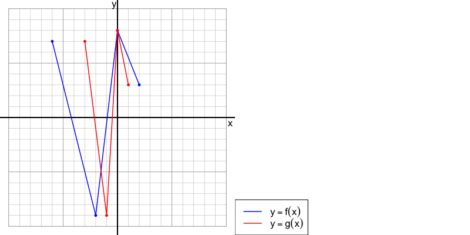

    What equation expresses the function transformation?
    1. $g(x)= f{\left(3\cdot x\right)}$
    2. $g(x)= f{\left(2\cdot x\right)}$
    3. $g(x)= f{\left(\frac{x}{3}\right)}$
    4. $g(x)=3\cdot f(x)$
    5. $g(x)= \frac{f(x)}{3}$
    6. $g(x)= \frac{f(x)}{2}$
    7. $g(x)=2\cdot f(x)$
    8. $g(x)= f{\left(\frac{x}{2}\right)}$

#### Solution

#### Question

37. The blue curve represents $y=f(x)$. The red curve represents $y=g(x)$.

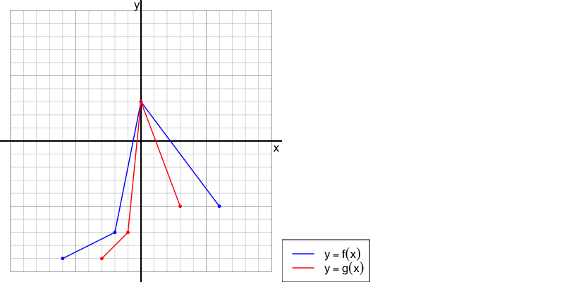

    What equation expresses the function transformation?
    1. $g(x)=2\cdot f(x)$
    2. $g(x)=3\cdot f(x)$
    3. $g(x)= f{\left(2\cdot x\right)}$
    4. $g(x)= \frac{f(x)}{2}$
    5. $g(x)= f{\left(3\cdot x\right)}$
    6. $g(x)= f{\left(\frac{x}{2}\right)}$
    7. $g(x)= f{\left(\frac{x}{3}\right)}$
    8. $g(x)= \frac{f(x)}{3}$

#### Solution

#### Question

38. The blue curve represents $y=f(x)$. The red curve represents $y=g(x)$.

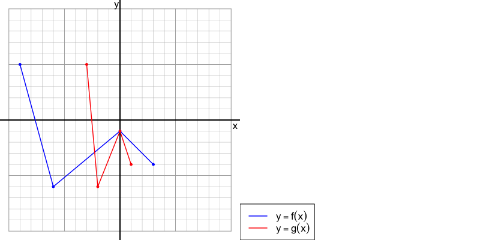

    What equation expresses the function transformation?
    1. $g(x)= \frac{f(x)}{2}$
    2. $g(x)=2\cdot f(x)$
    3. $g(x)=3\cdot f(x)$
    4. $g(x)= f{\left(\frac{x}{2}\right)}$
    5. $g(x)= f{\left(2\cdot x\right)}$
    6. $g(x)= \frac{f(x)}{3}$
    7. $g(x)= f{\left(3\cdot x\right)}$
    8. $g(x)= f{\left(\frac{x}{3}\right)}$

#### Solution

#### Question

39. The blue curve represents $y=f(x)$. The red curve represents $y=g(x)$.

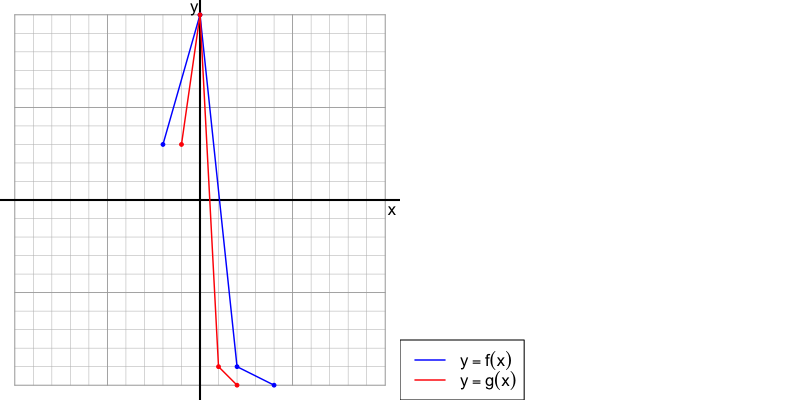

    What equation expresses the function transformation?
    1. $g(x)= \frac{f(x)}{3}$
    2. $g(x)= f{\left(\frac{x}{2}\right)}$
    3. $g(x)= f{\left(\frac{x}{3}\right)}$
    4. $g(x)= f{\left(2\cdot x\right)}$
    5. $g(x)= f{\left(3\cdot x\right)}$
    6. $g(x)=2\cdot f(x)$
    7. $g(x)=3\cdot f(x)$
    8. $g(x)= \frac{f(x)}{2}$

#### Solution

#### Question

40. The blue curve represents $y=f(x)$. The red curve represents $y=g(x)$.

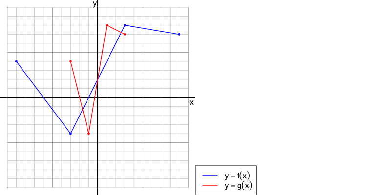

    What equation expresses the function transformation?
    1. $g(x)= \frac{f(x)}{3}$
    2. $g(x)= f{\left(3\cdot x\right)}$
    3. $g(x)=2\cdot f(x)$
    4. $g(x)=3\cdot f(x)$
    5. $g(x)= \frac{f(x)}{2}$
    6. $g(x)= f{\left(2\cdot x\right)}$
    7. $g(x)= f{\left(\frac{x}{2}\right)}$
    8. $g(x)= f{\left(\frac{x}{3}\right)}$

#### Solution

#### Question

41. The blue curve represents $y=f(x)$. The red curve represents $y=g(x)$.

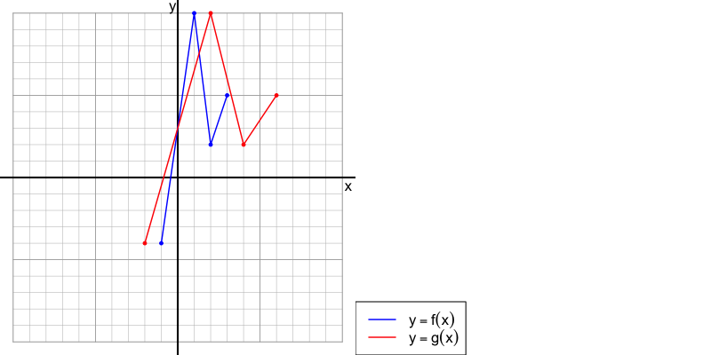

    What equation expresses the function transformation?
    1. $g(x)= f{\left(3\cdot x\right)}$
    2. $g(x)= f{\left(2\cdot x\right)}$
    3. $g(x)= \frac{f(x)}{3}$
    4. $g(x)= f{\left(\frac{x}{3}\right)}$
    5. $g(x)= f{\left(\frac{x}{2}\right)}$
    6. $g(x)= \frac{f(x)}{2}$
    7. $g(x)=2\cdot f(x)$
    8. $g(x)=3\cdot f(x)$

#### Solution

#### Question

42. The blue curve represents $y=f(x)$. The red curve represents $y=g(x)$.

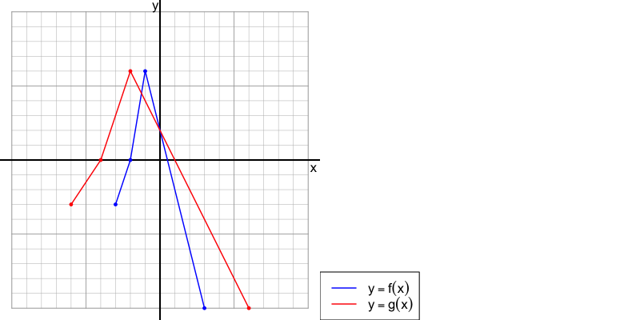

    What equation expresses the function transformation?
    1. $g(x)= f{\left(\frac{x}{3}\right)}$
    2. $g(x)= \frac{f(x)}{2}$
    3. $g(x)=2\cdot f(x)$
    4. $g(x)= f{\left(3\cdot x\right)}$
    5. $g(x)= f{\left(2\cdot x\right)}$
    6. $g(x)=3\cdot f(x)$
    7. $g(x)= \frac{f(x)}{3}$
    8. $g(x)= f{\left(\frac{x}{2}\right)}$

#### Solution

#### Question

43. The blue curve represents $y=f(x)$. The red curve represents $y=g(x)$.

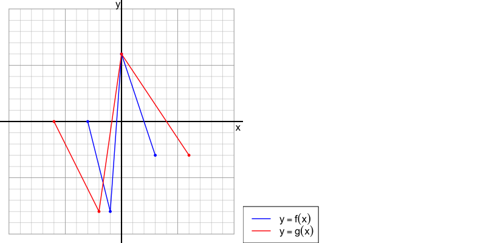

    What equation expresses the function transformation?
    1. $g(x)= \frac{f(x)}{2}$
    2. $g(x)=3\cdot f(x)$
    3. $g(x)= \frac{f(x)}{3}$
    4. $g(x)= f{\left(\frac{x}{2}\right)}$
    5. $g(x)=2\cdot f(x)$
    6. $g(x)= f{\left(2\cdot x\right)}$
    7. $g(x)= f{\left(3\cdot x\right)}$
    8. $g(x)= f{\left(\frac{x}{3}\right)}$

#### Solution

#### Question

44. The blue curve represents $y=f(x)$. The red curve represents $y=g(x)$.

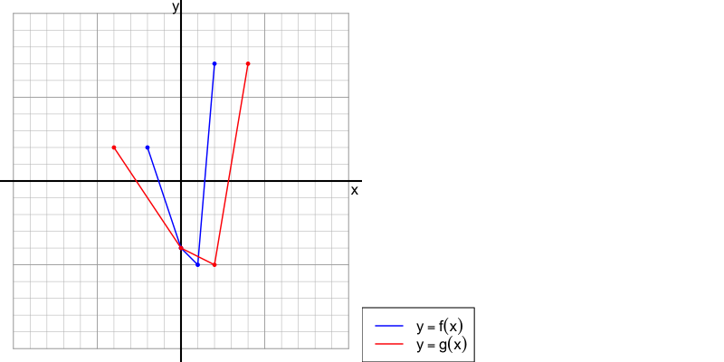

    What equation expresses the function transformation?
    1. $g(x)=2\cdot f(x)$
    2. $g(x)= \frac{f(x)}{2}$
    3. $g(x)= f{\left(\frac{x}{2}\right)}$
    4. $g(x)= \frac{f(x)}{3}$
    5. $g(x)= f{\left(\frac{x}{3}\right)}$
    6. $g(x)=3\cdot f(x)$
    7. $g(x)= f{\left(2\cdot x\right)}$
    8. $g(x)= f{\left(3\cdot x\right)}$

#### Solution

#### Question

45. The blue curve represents $y=f(x)$. The red curve represents $y=g(x)$.

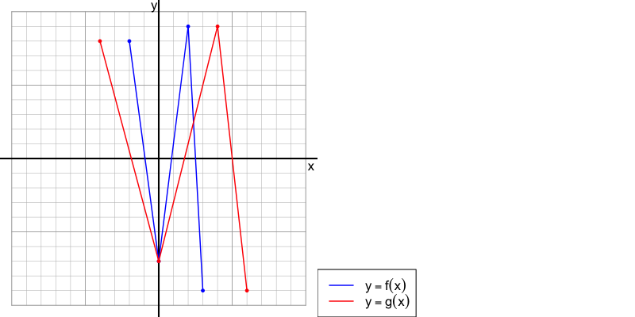

    What equation expresses the function transformation?
    1. $g(x)= \frac{f(x)}{2}$
    2. $g(x)= \frac{f(x)}{3}$
    3. $g(x)= f{\left(3\cdot x\right)}$
    4. $g(x)= f{\left(\frac{x}{3}\right)}$
    5. $g(x)= f{\left(\frac{x}{2}\right)}$
    6. $g(x)=2\cdot f(x)$
    7. $g(x)= f{\left(2\cdot x\right)}$
    8. $g(x)=3\cdot f(x)$

#### Solution

#### Question

46. The blue curve represents $y=f(x)$. The red curve represents $y=g(x)$.

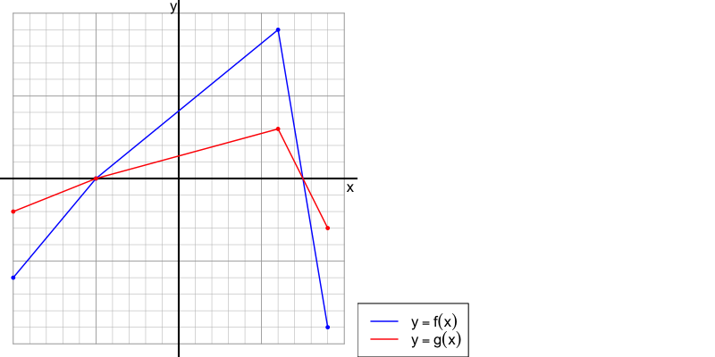

    What equation expresses the function transformation?
    1. $g(x)= \frac{f(x)}{3}$
    2. $g(x)=3\cdot f(x)$
    3. $g(x)= f{\left(\frac{x}{2}\right)}$
    4. $g(x)=2\cdot f(x)$
    5. $g(x)= f{\left(2\cdot x\right)}$
    6. $g(x)= f{\left(\frac{x}{3}\right)}$
    7. $g(x)= f{\left(3\cdot x\right)}$
    8. $g(x)= \frac{f(x)}{2}$

#### Solution

#### Question

47. The blue curve represents $y=f(x)$. The red curve represents $y=g(x)$.

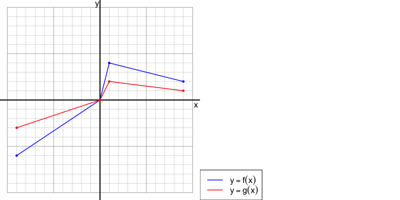

    What equation expresses the function transformation?
    1. $g(x)=2\cdot f(x)$
    2. $g(x)= \frac{f(x)}{3}$
    3. $g(x)= \frac{f(x)}{2}$
    4. $g(x)= f{\left(\frac{x}{3}\right)}$
    5. $g(x)=3\cdot f(x)$
    6. $g(x)= f{\left(\frac{x}{2}\right)}$
    7. $g(x)= f{\left(3\cdot x\right)}$
    8. $g(x)= f{\left(2\cdot x\right)}$

#### Solution

#### Question

48. The blue curve represents $y=f(x)$. The red curve represents $y=g(x)$.

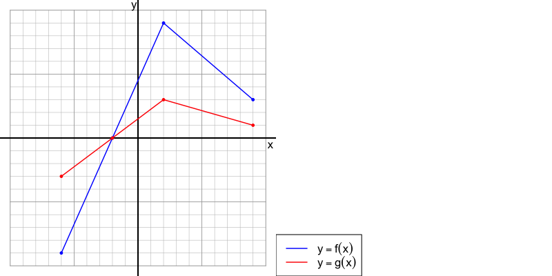

    What equation expresses the function transformation?
    1. $g(x)= f{\left(2\cdot x\right)}$
    2. $g(x)= \frac{f(x)}{2}$
    3. $g(x)= \frac{f(x)}{3}$
    4. $g(x)= f{\left(\frac{x}{2}\right)}$
    5. $g(x)=3\cdot f(x)$
    6. $g(x)= f{\left(3\cdot x\right)}$
    7. $g(x)= f{\left(\frac{x}{3}\right)}$
    8. $g(x)=2\cdot f(x)$

#### Solution

#### Question

49. The blue curve represents $y=f(x)$. The red curve represents $y=g(x)$.

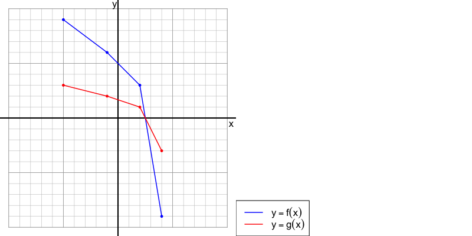

    What equation expresses the function transformation?
    1. $g(x)= f{\left(\frac{x}{2}\right)}$
    2. $g(x)= f{\left(2\cdot x\right)}$
    3. $g(x)= f{\left(\frac{x}{3}\right)}$
    4. $g(x)=2\cdot f(x)$
    5. $g(x)= \frac{f(x)}{2}$
    6. $g(x)= f{\left(3\cdot x\right)}$
    7. $g(x)=3\cdot f(x)$
    8. $g(x)= \frac{f(x)}{3}$

#### Solution

#### Question

50. The blue curve represents $y=f(x)$. The red curve represents $y=g(x)$.

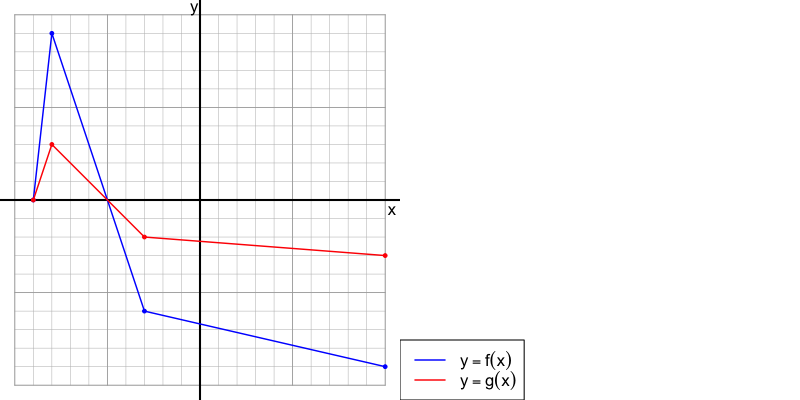

    What equation expresses the function transformation?
    1. $g(x)= f{\left(\frac{x}{2}\right)}$
    2. $g(x)=3\cdot f(x)$
    3. $g(x)=2\cdot f(x)$
    4. $g(x)= f{\left(\frac{x}{3}\right)}$
    5. $g(x)= f{\left(3\cdot x\right)}$
    6. $g(x)= \frac{f(x)}{3}$
    7. $g(x)= f{\left(2\cdot x\right)}$
    8. $g(x)= \frac{f(x)}{2}$

#### Solution

#### Question

51. The blue curve represents $y=f(x)$. The red curve represents $y=g(x)$.

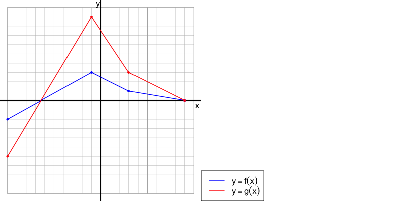

    What equation expresses the function transformation?
    1. $g(x)= \frac{f(x)}{3}$
    2. $g(x)= f{\left(2\cdot x\right)}$
    3. $g(x)= f{\left(\frac{x}{2}\right)}$
    4. $g(x)= f{\left(3\cdot x\right)}$
    5. $g(x)= \frac{f(x)}{2}$
    6. $g(x)=2\cdot f(x)$
    7. $g(x)=3\cdot f(x)$
    8. $g(x)= f{\left(\frac{x}{3}\right)}$

#### Solution

#### Question

52. The blue curve represents $y=f(x)$. The red curve represents $y=g(x)$.

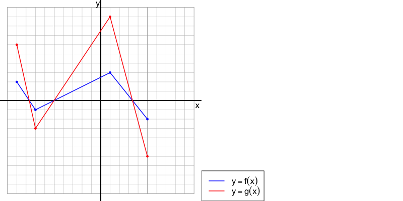

    What equation expresses the function transformation?
    1. $g(x)= f{\left(\frac{x}{2}\right)}$
    2. $g(x)= f{\left(\frac{x}{3}\right)}$
    3. $g(x)= f{\left(3\cdot x\right)}$
    4. $g(x)=2\cdot f(x)$
    5. $g(x)= f{\left(2\cdot x\right)}$
    6. $g(x)=3\cdot f(x)$
    7. $g(x)= \frac{f(x)}{2}$
    8. $g(x)= \frac{f(x)}{3}$

#### Solution

#### Question

53. The blue curve represents $y=f(x)$. The red curve represents $y=g(x)$.

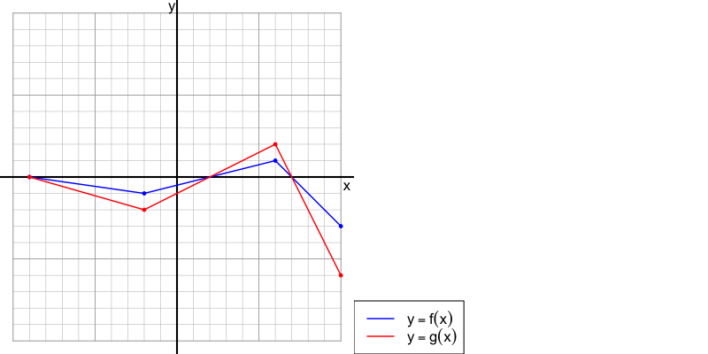

    What equation expresses the function transformation?
    1. $g(x)= f{\left(2\cdot x\right)}$
    2. $g(x)= f{\left(\frac{x}{2}\right)}$
    3. $g(x)= f{\left(\frac{x}{3}\right)}$
    4. $g(x)=2\cdot f(x)$
    5. $g(x)= f{\left(3\cdot x\right)}$
    6. $g(x)=3\cdot f(x)$
    7. $g(x)= \frac{f(x)}{3}$
    8. $g(x)= \frac{f(x)}{2}$

#### Solution

#### Question

54. The blue curve represents $y=f(x)$. The red curve represents $y=g(x)$.

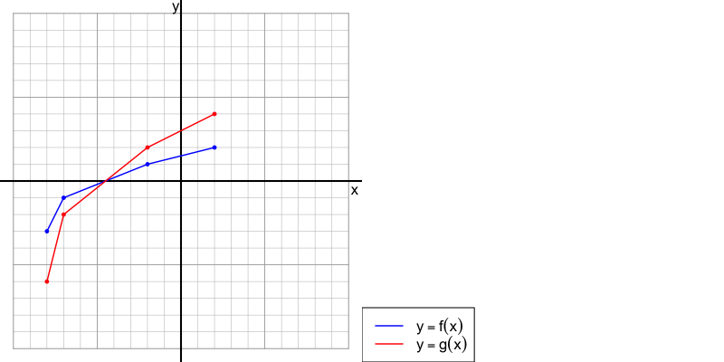

    What equation expresses the function transformation?
    1. $g(x)= f{\left(\frac{x}{2}\right)}$
    2. $g(x)=2\cdot f(x)$
    3. $g(x)= \frac{f(x)}{2}$
    4. $g(x)= f{\left(2\cdot x\right)}$
    5. $g(x)= \frac{f(x)}{3}$
    6. $g(x)= f{\left(3\cdot x\right)}$
    7. $g(x)= f{\left(\frac{x}{3}\right)}$
    8. $g(x)=3\cdot f(x)$

#### Solution

#### Question

55. The blue curve represents $y=f(x)$. The red curve represents $y=g(x)$.

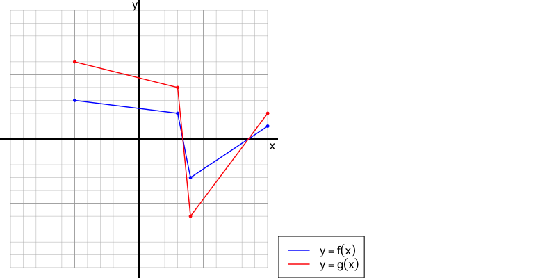

    What equation expresses the function transformation?
    1. $g(x)= f{\left(3\cdot x\right)}$
    2. $g(x)= \frac{f(x)}{2}$
    3. $g(x)=2\cdot f(x)$
    4. $g(x)=3\cdot f(x)$
    5. $g(x)= f{\left(2\cdot x\right)}$
    6. $g(x)= \frac{f(x)}{3}$
    7. $g(x)= f{\left(\frac{x}{2}\right)}$
    8. $g(x)= f{\left(\frac{x}{3}\right)}$

#### Solution